# F9_06_GVRN_NUM_VOTING_MEMB_IND

Number of independent voting members of governing body · Number report

## Overview

**Description**

Number of independent voting members

**Table**

`F9-P06-T00-GOVERNANCE` (one)

**Location code**

`F990-PC-PART-06-SECTION-A-LINE-01B`

**Family**

`F990-PC-PART-06-SECTION-A-LINE-01B`

**Data type**

numeric (xsd: , CountType)

**Scope**

PC

**Status**

unreviewed

3

xpaths mapped (2 observed)

3,845,141

filings with a value

2009–2024

tax years observed

1

open flags (0 errors)

## Flags

| Severity | Flag | Xpath | Detail |
| --- | --- | --- | --- |
| ⓘ info | `UNOBSERVED` | IRS990/Form990PartVI/NumberIndependentVotingMembers | never observed in TY2009-2024 filings |

## Xpaths

All mapped xpaths (under /Return/ReturnData or /Return/ReturnHeader), oldest first. Charts label each series by its xpath.

| Xpath | Form | First year | Last year | Versions | Filings | Repeats in |
| --- | --- | --- | --- | --- | --- | --- |
| IRS990/NumberIndependentVotingMembers | 990 | 2009 | 2012 | 19 | 495,528 | 0.0% |
| IRS990/IndependentVotingMemberCnt | 990 | 2013 | 2024 | 38 | 3,349,613 | 0.0% |
| IRS990/Form990PartVI/NumberIndependentVotingMembers | 990 |  |  |  | 0 |  |

## Coverage

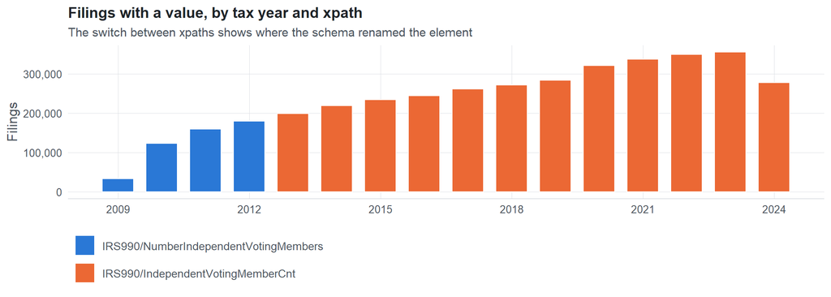

**Table view**

Table view: filings by tax year and series

| Tax year | IRS990/NumberIndependentVotingMembers | IRS990/IndependentVotingMemberCnt |
| --- | --- | --- |
| 2009 | 33,311 | 0 |
| 2010 | 123,025 | 0 |
| 2011 | 159,504 | 0 |
| 2012 | 179,688 | 0 |
| 2013 | 0 | 198,855 |
| 2014 | 0 | 218,619 |
| 2015 | 0 | 233,519 |
| 2016 | 0 | 243,903 |
| 2017 | 0 | 261,612 |
| 2018 | 0 | 271,442 |
| 2019 | 0 | 283,694 |
| 2020 | 0 | 320,343 |
| 2021 | 0 | 336,488 |
| 2022 | 0 | 349,062 |
| 2023 | 0 | 354,774 |
| 2024 | 0 | 277,302 |

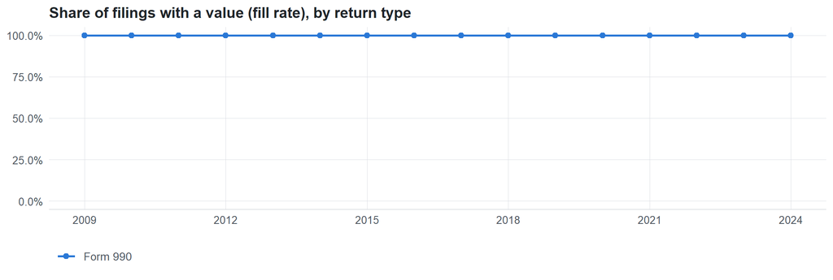

**Table view**

Table view: fill rate

| Tax year | Return type | Filings | All filings | Fill rate |
| --- | --- | --- | --- | --- |
| 2009 | Form 990 | 33,311 | 33,311 | 100.00% |
| 2010 | Form 990 | 123,025 | 123,025 | 100.00% |
| 2011 | Form 990 | 159,504 | 159,504 | 100.00% |
| 2012 | Form 990 | 179,688 | 179,688 | 100.00% |
| 2013 | Form 990 | 198,855 | 198,855 | 100.00% |
| 2014 | Form 990 | 218,619 | 218,619 | 100.00% |
| 2015 | Form 990 | 233,519 | 233,519 | 100.00% |
| 2016 | Form 990 | 243,903 | 243,903 | 100.00% |
| 2017 | Form 990 | 261,612 | 261,612 | 100.00% |
| 2018 | Form 990 | 271,442 | 271,442 | 100.00% |
| 2019 | Form 990 | 283,694 | 283,694 | 100.00% |
| 2020 | Form 990 | 320,342 | 320,342 | 100.00% |
| 2021 | Form 990 | 336,480 | 336,480 | 100.00% |
| 2022 | Form 990 | 349,055 | 349,055 | 100.00% |
| 2023 | Form 990 | 354,768 | 354,768 | 100.00% |
| 2024 | Form 990 | 277,298 | 277,298 | 100.00% |

## Values

| Result | Check | Detail |
| --- | --- | --- |
| ✓ pass | Values parse as numbers | 100.0% of values are numeric |
| ✓ pass | No sudden change in the median between adjacent years | largest change 1.2x (IRS990/NumberIndependentVotingMembers, 990, TY2010) |
| ✓ pass | Pooled xpaths are on the same scale (same return type) | largest ratio of medians between xpaths: 1.1x |
| ⚠ fail | One scale across xpaths (fraction vs percent) | IRS990/IndependentVotingMemberCnt: large count or amount; IRS990/NumberIndependentVotingMembers: percent or small count |

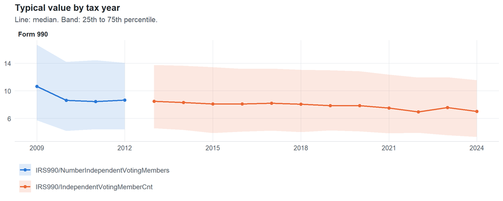

**Table view**

Table view: quartiles by tax year

| Series | Return | Tax year | Filings | P25 | Median | P75 |
| --- | --- | --- | --- | --- | --- | --- |
| IRS990/NumberIndependentVotingMembers | 990 | 2009 | 33,311 | 5.74 | 10.63 | 16.69 |
| IRS990/NumberIndependentVotingMembers | 990 | 2010 | 123,025 | 4.19 | 8.63 | 14.19 |
| IRS990/NumberIndependentVotingMembers | 990 | 2011 | 159,504 | 4.43 | 8.44 | 14.44 |
| IRS990/NumberIndependentVotingMembers | 990 | 2012 | 179,688 | 4.40 | 8.66 | 14.06 |
| IRS990/IndependentVotingMemberCnt | 990 | 2013 | 198,855 | 4.58 | 8.48 | 13.74 |
| IRS990/IndependentVotingMemberCnt | 990 | 2014 | 218,619 | 4.32 | 8.32 | 13.64 |
| IRS990/IndependentVotingMemberCnt | 990 | 2015 | 233,519 | 3.89 | 8.10 | 13.42 |
| IRS990/IndependentVotingMemberCnt | 990 | 2016 | 243,903 | 4.09 | 8.09 | 13.18 |
| IRS990/IndependentVotingMemberCnt | 990 | 2017 | 261,612 | 4.23 | 8.21 | 13.21 |
| IRS990/IndependentVotingMemberCnt | 990 | 2018 | 271,442 | 4.02 | 8.06 | 13.05 |
| IRS990/IndependentVotingMemberCnt | 990 | 2019 | 283,694 | 4.26 | 7.84 | 12.97 |
| IRS990/IndependentVotingMemberCnt | 990 | 2020 | 320,342 | 4.13 | 7.84 | 12.84 |
| IRS990/IndependentVotingMemberCnt | 990 | 2021 | 336,480 | 3.84 | 7.50 | 12.35 |
| IRS990/IndependentVotingMemberCnt | 990 | 2022 | 349,055 | 3.93 | 6.95 | 11.93 |
| IRS990/IndependentVotingMemberCnt | 990 | 2023 | 354,768 | 3.57 | 7.58 | 11.95 |
| IRS990/IndependentVotingMemberCnt | 990 | 2024 | 277,298 | 3.31 | 7.01 | 11.54 |

Summary by xpath and return type (all years)

| Series | Return | Filings | % numeric | % zero | % negative | Median (typical year) | P99 (typical year) |
| --- | --- | --- | --- | --- | --- | --- | --- |
| IRS990/NumberIndependentVotingMembers | 990 | 495,528 | 100 | 11.89 | 0 | 9 | 100 |
| IRS990/IndependentVotingMemberCnt |  | 26 |  |  |  |  |  |
| IRS990/IndependentVotingMemberCnt | 990 | 3,349,587 | 100 | 12.00 | 0 | 8 | 128 |

Scale of each xpath

| Series | P99 (typical year) | Implied scale |
| --- | --- | --- |
| IRS990/IndependentVotingMemberCnt | 128 | large count or amount |
| IRS990/NumberIndependentVotingMembers | 100 | percent or small count |

## Examples

| Tax year | Return | Xpath | Organization | Value | Source |
| --- | --- | --- | --- | --- | --- |
| 2024 | 990 | IRS990/IndependentVotingMemberCnt | CHRISTIAN SHANE FONVILLE YOUTH | 0 | [XML](https://gt990datalake-rawdata.s3.amazonaws.com/EfileData/XmlFiles/202511059349301411_public.xml) |
| 2023 | 990 | IRS990/IndependentVotingMemberCnt | MACKINAC ASSOCIATES | 13 | [XML](https://gt990datalake-rawdata.s3.amazonaws.com/EfileData/XmlFiles/202530469349300808_public.xml) |
| 2022 | 990 | IRS990/IndependentVotingMemberCnt | BRANDYWINE VFW POST 845 | 411 | [XML](https://gt990datalake-rawdata.s3.amazonaws.com/EfileData/XmlFiles/202311649349300031_public.xml) |
| 2021 | 990 | IRS990/IndependentVotingMemberCnt | COULEE REGION HUMANE SOCIETY INC | 11 | [XML](https://gt990datalake-rawdata.s3.amazonaws.com/EfileData/XmlFiles/202243119349301379_public.xml) |
| 2020 | 990 | IRS990/IndependentVotingMemberCnt | PROJECT ALLAHU AKBAR | 0 | [XML](https://gt990datalake-rawdata.s3.amazonaws.com/EfileData/XmlFiles/202103199349300805_public.xml) |
| 2019 | 990 | IRS990/IndependentVotingMemberCnt | Chauffeurs Teamsters & Helpers Local 878 | 0 | [XML](https://gt990datalake-rawdata.s3.amazonaws.com/EfileData/XmlFiles/202043219349315409_public.xml) |
| 2018 | 990 | IRS990/IndependentVotingMemberCnt | FORT PAYNE CHAMBER OF COMMERCE | 15 | [XML](https://gt990datalake-rawdata.s3.amazonaws.com/EfileData/XmlFiles/201931359349306873_public.xml) |
| 2017 | 990 | IRS990/IndependentVotingMemberCnt | INTOWN COLLABORATIVE MINISTRIES INC | 14 | [XML](https://gt990datalake-rawdata.s3.amazonaws.com/EfileData/XmlFiles/201921099349300617_public.xml) |
| 2016 | 990 | IRS990/IndependentVotingMemberCnt | THE ASSOC OF MARITAL & FAMILY | 0 | [XML](https://gt990datalake-rawdata.s3.amazonaws.com/EfileData/XmlFiles/201721319349304097_public.xml) |
| 2015 | 990 | IRS990/IndependentVotingMemberCnt | WOODBRIDGE LODGE NO 2355 OF THE | 5 | [XML](https://gt990datalake-rawdata.s3.amazonaws.com/EfileData/XmlFiles/201612569349300701_public.xml) |
| 2014 | 990 | IRS990/IndependentVotingMemberCnt | JUDGES AND LAWYERS BREAST CANCER ALERT | 78 | [XML](https://gt990datalake-rawdata.s3.amazonaws.com/EfileData/XmlFiles/201601249349301520_public.xml) |
| 2013 | 990 | IRS990/IndependentVotingMemberCnt | NORTH BRUNSWICK BASEBALL ASSOCIATION INC | 0 | [XML](https://gt990datalake-rawdata.s3.amazonaws.com/EfileData/XmlFiles/201402549349300330_public.xml) |

## Reviewer checklist

- The definition matches the form line and instructions for every xpath’s schema years.
- Every xpath pooled here measures the same thing on the 990 and 990-EZ (close enough for analysis).
- The coverage chart has no unexplained gaps or jumps between tax years.
- Each open flag is fixed, or accepted with a note in validation_log.csv.
- Counts are whole numbers and plausible (e.g. employees, volunteers, voting members).
- Ratios and percentages use one scale (0-1 or 0-100) across all xpaths and years.
- Units match the form line (hours per week, number of states, percent of support).

Record the review as a row in `inst/extdata/src/validation_log.csv` (variable_name, reviewer, date, status, note). Evidence built 2026-09-23 17:09:04 MST from the ef2 DuckDB builds (tax years 2009–2024).